# Modello+conigato_Poisson_Gamma

NikolayNikolaev

2023-05-29

# Modello coniugato Poisson-Gamma

Si intende stimare il tasso di occorrenza nell’unità di tempo (2 mesi) del numero di decessi avvenuti in una regione a seguito di una certa operazione chirurgica.

Sapendo che nei due mesi precedenti sono avvenuti 16 decessi in 10 ospedali che hanno operato in totale 15174 pazienti. La distribuzione a priori è

$$p(\lambda)= Gamma(\alph,
\beta)$$

Rilevando oggi che in un altro ospedale della regione c’è stato un decesso a seguito di 66 operazioni su pazienti diversi, con il modello coniugato la distribuzione a posteriori è
$$p(\lambda |y) = Gamma(\alpha + \sum_i x_i,
\beta+n)$$

i cui parametri $\alpha_1 = 17$ and $\beta_1 = 15240$

## Rappresentazioni grafiche

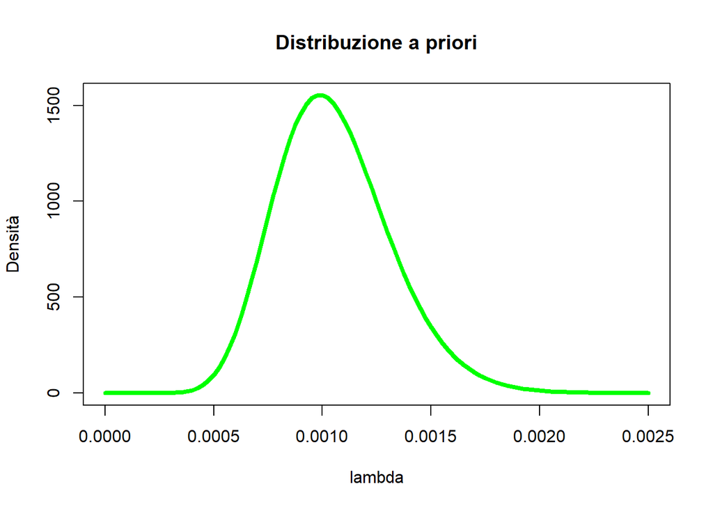

```r
alpha <- 16
beta <- 15174
curve(dgamma(x,alpha,beta),
  xlab="lambda",
  ylab="Densità",
  type = "l",
  xlim=c(0,0.0025),
  lwd=4,
  col="green",
  main ="Distribuzione a priori")
```

## Distribuzione di Poisson

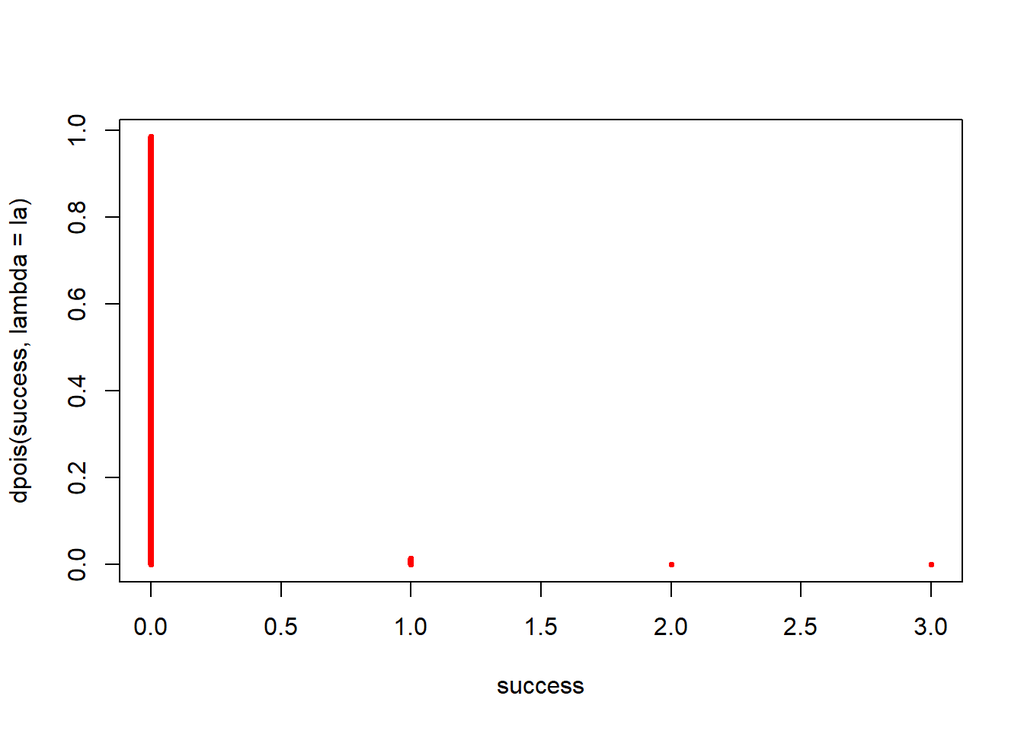

```r
success <- 0:3
la <- 1/66
plot(success, dpois(success, lambda=la), type = "h",
  lwd=4,
  col = "red")
```

## Rappresentazione della distribuzione a posteriori

In base alle osservazioni campionarie la distribuzione a posteriori per il parametro è la seguente

```r
n<-66
alpha1<- alpha + 1; alpha1
```

```
## [1] 17
```

```r
beta1 <- beta + n; beta1
```

```
## [1] 15240
```

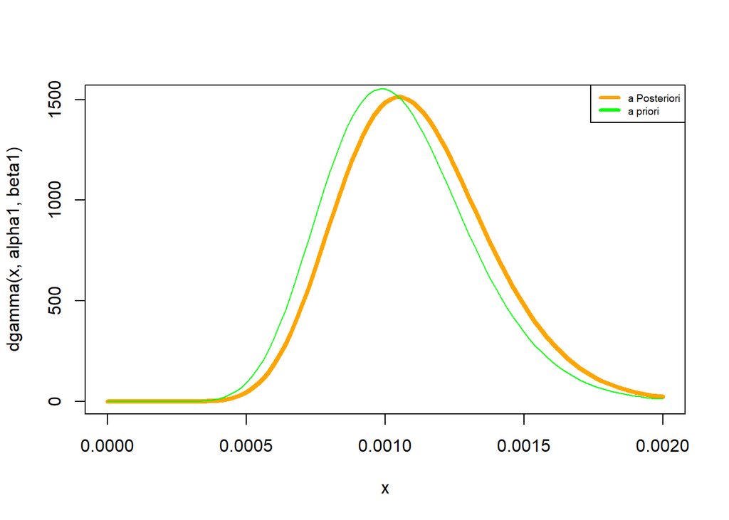

```r
curve(dgamma(x,alpha1,beta1),
  lty=1,
  lwd=4,
  xlim=c(0,0.002),
  col="orange",
  main = " ")
# prior
curve(dgamma(x, alpha, beta),
    lty=1,
    lwd=1,
    col="green",
    add=TRUE)
legend("topright",
    c("a Posteriori", "a priori"),
    lwd=c(3,3),
    cex = 0.6,
    col=c("orange","green" ))
```

Il valore atteso in base alla distribuzione a posteriori per il tasso dei decessi mensili è

```r
Elambda <- (alpha+1)/(beta+n); Elambda
```

```
## [1] 0.001115486
```

con variabilità media intorno alla media pari a

```r
sqrt(alpha1/((beta1)^2))
```

```
## [1] 0.000270545
```

```r
ex <- 1767
ys <- 0:10
(alpha/beta)*ex
```

```
## [1] 1.863187
```

```r
pyn1 <- dpois(ys, (alpha/beta)*ex)*
  dgamma(alpha/beta, shape = alpha, rate = beta)/
  dgamma(alpha1/beta1, shape = alpha1 + ys,
         rate = beta1 + ex)
cbind(ys, round(pyn1, 3))
```

```
##       ys
##  [1,]  0 0.177
##  [2,]  1 0.296
##  [3,]  2 0.261
##  [4,]  3 0.163
##  [5,]  4 0.080
##  [6,]  5 0.033
##  [7,]  6 0.012
##  [8,]  7 0.004
##  [9,]  8 0.001
## [10,]  9 0.000
## [11,] 10 0.000
```

Tra gli eventi previsti quello con massima probabilità è 1 decesso, seguito da 2 decessi e 0 decessi.

Essendo plausibili tutti i valori speficicati notiamo che il modello Bayesiano è stato correttamente specificato.